# Part II - Airline Passenger Satisfaction Dataset Presentation

## by Haifaa Mohamad Alzahrani

## Investigation Overview

**The main goals:**

- Get the percentage of passengers in each class
- Analyse the relationship between satisfaction and classes
- Analyse the relationship between satisfaction and classes and online boarding as it is an important feature

**The key insights:**

- The number of passengers from Business class is too close to the number of Eco class, but the number of Eco Plus is very small.
- A huge number (40000+) of passengers from Eco class were neutral or dissatisfied against only about 10000 satisfied.
- A huge number (40000+) of passengers from the Business class were satisfied against only about 20000 neutral or dissatisfied.
- Most of the passengers from Eco Plus were neutral or dissatisfied.
- Overall, passengers from Eco and Eco Plus classes who are neutral or dissatisfied have a high level of agreement with each other on online boarding (2-3) with small number of outliers.
- For Business class, the passengers who were neutral or dissatisfied have a more diverse (2-4) with no outliers for online boarding.
- The observations from Eco and Eco Plus and who are satisfied, have a wider range of opinions (3-5) with no outliers.
- For Business class and who are satisfied, it shows high level of agreement (4-5) with some outliers regarding online boarding.

## Dataset Overview

**Airline Passenger Satisfaction** dataset is published by [Kaggle](https://www.kaggle.com/datasets/teejmahal20/airline-passenger-satisfaction?resource=download) and contains an airline passenger satisfaction survey. It provides 129880 observations with 24 different factors to help analyze the passenger's satisfaction.

## (Visualization 1)

Percentage of passengers according to class

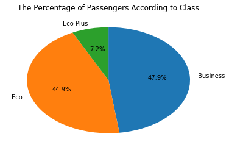

The percent of passengers on Business class is too close to the percent of Eco class, but the percent of Eco Plus is very small. However, we need to focus on both Eco and Business classes to analyse thier satisfaction.

## (Visualization 2)

The relationship between satisfaction and class

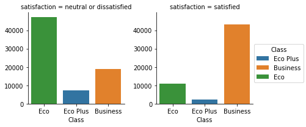

Interestingly, a huge number (40000+) of passengers from Eco class were neutral or dissatisfied against only about 10000 satisfied. On the contrary, a huge number (40000+) of passengers from the Business class were satisfied against only about 20000 neutral or dissatisfied. Finally, most of the passengers from Eco Plus were neutral or dissatisfied.

## (Visualization 3)

The relationship between satisfaction, class, and online boarding

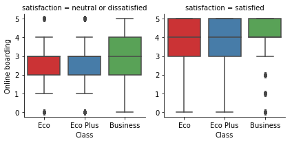

**For neutral or dissatisfied & Online Boarding:**

- The box plots for Eco and Eco Plus classes suggest that overall passengers have a high level of agreement with each other on online boarding (2-3) with small number of outliers.
- For Business class, the observations have a more diverse (2-4) with no outliers.

**For satisfied & Online Boarding:**

- The box plots for Eco and Eco Plus classes suggest that observations have a wider range of opinions (3-5) with no outliers.
- For Business class, it shows high level of agreement (4-5) with some outliers.